# S2

## Setup

```r
source('../resources/aes.R')
da_md = read.csv('../preprocessing/data/import/metadata-donor.csv') %>% mutate(diagnosis=cohort)
dir.create('../figures/S2')
```

## Overview N donor/cells ig predicted

```r
m_id = read.csv('../preprocessing/data/mPC_id.csv')

m_id %>% filter(!donor_id %in% donors.longit) %>% dim()
```

```
## [1] 67025    15
```

```r
m_id %>% filter(!donor_id %in% donors.longit) %>% pull(donor_id) %>% unique() %>% length()
```

```
## [1] 45
```

```r
pc_n = m_id %>% filter(!donor_id %in% donors.longit) %>% group_by(donor_id) %>% tally() %>% .$n
median(pc_n)
```

```
## [1] 466
```

```r
range(pc_n)
```

```
## [1]    76 13638
```

## S2A

Data prep

```r
m_id = read.csv('../preprocessing/data/mPC_id.csv')

gene_n = m_id %>% select(donor_id,lightV1,lightV2,IGHV1,IGHV2,IGHC1,IGHC2) %>%
  pivot_longer(!donor_id,names_to='gene') %>% filter(value!='') %>%
  group_by(donor_id,gene,value) %>% tally() %>% ungroup() %>%
  left_join(data.frame(gene=c('lightV1','lightV2','IGHV1','IGHV2','IGHC1','IGHC2'),
    group=c('light','light','IGHV','IGHV','IGHC','IGHC'),
    rank=c(1,2,1,2,1,2))) %>%
  arrange(-n)
ig_gene_group = data.frame()
for (g in c('lightV','IGHC','IGHV')){
  gs=unique(c(m_id[[paste0(g,1)]],m_id[[paste0(g,1)]]))
  ig_gene_group = rbind(ig_gene_group,data.frame(gene=gs,group=rep(g,length(gs))) )
}
ig_gene_group = ig_gene_group %>% filter(gene!='')

m_id_pl = m_id %>% filter(!donor_id %in% donors.longit) %>%
  select(donor_id,lightV1,IGHV1,IGHC1) %>% pivot_longer(!donor_id,names_to='chain',values_to='g') %>%
  filter(g!='') %>%
  group_by(donor_id,chain,g) %>% tally() %>% ungroup() %>%
  group_by(donor_id,chain) %>% mutate(pct=n/sum(n)*100) %>% ungroup() %>%
  mutate(x=paste0(donor_id,chain,g)) %>% arrange(pct) %>% mutate(x=factor(x,x)) %>%
  arrange(-n) %>% group_by(donor_id,chain) %>%
  mutate(rank=row_number()) %>% ungroup() %>%
  mutate(rank=factor(ifelse(rank %in% 1:2,rank,'<2'),c(1,2,'<2'))) %>%
  left_join(data.frame(
    chain=c("lightV1","IGHC1","IGHV1"),
    chain.pl=c('Light variable','Heavy constant','Heavy variable')
  )) %>% mutate(chain.pl=factor(chain.pl, c('Light variable','Heavy constant','Heavy variable')))
# Quantify rank 1 %s
tmp = m_id_pl %>% filter(rank==1) %>% group_by(chain.pl) %>%
  summarise(med=median(pct), r1=range(pct)[1], r2=range(pct)[2])
print(tmp)
```

```
## # A tibble: 3 × 4
##   chain.pl         med    r1    r2
##   <fct>          <dbl> <dbl> <dbl>
## 1 Light variable  95.0  31.1   100
## 2 Heavy constant  96.4  34.6   100
## 3 Heavy variable  91    24.1   100
```

Plotting

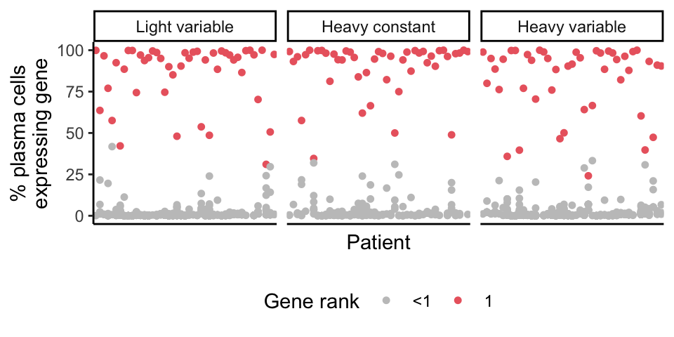

```r
donor.order = m_id_pl %>% filter(chain=='lightV1',rank==1) %>% arrange(-pct) %>% pull(donor_id)
m_id_pl_sub = m_id_pl %>% filter(donor_id==donor.order[27],rank!='<2',chain=='lightV1')

m_id_pl %>%
  mutate(rank=ifelse(rank==1,1,'<1')) %>%
  ggplot(aes(donor_id,pct))+facet_grid(~chain.pl)+
  geom_point(aes(color=rank),size=1.25)+
    scale_color_manual(values = setNames(c('#eb676e','grey77'),c(1,'<1')))+
  labs(x='Patient',y='% plasma cells\nexpressing gene',color='Gene rank')+
  theme(axis.text.x=element_blank(), axis.ticks.x=element_blank(),
        legend.position = 'bottom') -> pl
pl
```

```r
ggsave(plot=pl,filename = '../figures/S2/A.pdf',width=5,height=2.5, dpi="retina")
```

## Quantify most abundant Ig chains

- https://ashpublications.org/blood/article/110/9/3112/23967/Immunoglobulin-gene-rearrangements-and-the
  - VH3-30 (*IGHV*) has been consistently found to be preferentially rearranged in myeloma, followed by VH5-51, VH1-69, and VH3-23. H3-30 and VH3-23 are the most frequently used gene segments both in normal and malignant B-cell populations, not MM-specific
  - Most of the studies show a clear preference for Vκ1 (*IGKV*) family usage (53% of the total), followed by Vκ3 (25%); align w healthy B
  - a few Vκ1 (*IGKV*) gene segments seem to be used very often; these include the Vκ1-33/1D-33, Vκ1-39/1D-39, and Vκ1-6 gene segments
  - Studies dealing with Vλ (*IGLV*) usage in Igλ myeloma cases show largely equal Vλ1 (27%), Vλ2 (29%), and Vλ3 (41%) family usage (Table 4).46,59,77,78 Within these families, no clear preference for individual gene segments was observed.

```r
m_id_pl %>% filter(rank==1,chain!='IGHC1') %>%
  group_by(chain,g) %>% tally() %>% arrange(-n) %>% filter(n>1)
```

```
## # A tibble: 28 × 3
## # Groups:   chain [2]
##    chain   g            n
##    <chr>   <chr>    <int>
##  1 lightV1 IGKV1-12     4
##  2 lightV1 IGLV3-21     4
##  3 IGHV1   IGHV1-18     3
##  4 IGHV1   IGHV1-24     3
##  5 IGHV1   IGHV2-70     3
##  6 IGHV1   IGHV3-11     3
##  7 IGHV1   IGHV3-30     3
##  8 IGHV1   IGHV3-33     3
##  9 IGHV1   IGHV3-7      3
## 10 IGHV1   IGHV6-1      3
## # ℹ 18 more rows
```

```r
common.IGH = c('IGHV3-30',"IGHV5-51", 'IGHV1-69', 'IGHV3-23')
for (g in common.IGH ){print(paste0(g,'   ', g %in% unique(c(m_id$IGHV1,m_id$IGHV2))))}
```

```
## [1] "IGHV3-30   TRUE"
## [1] "IGHV5-51   TRUE"
## [1] "IGHV1-69   TRUE"
## [1] "IGHV3-23   TRUE"
```

```r
common.lightV = c('IGKV1-33','IGKV1D-33','IGKV1-39','IGKV1D-39','IGKV1-6')
for (g in common.lightV ){print(paste0(g,'   ', g %in% unique(c(m_id$lightV1,m_id$lightV2))))}
```

```
## [1] "IGKV1-33   TRUE"
## [1] "IGKV1D-33   TRUE"
## [1] "IGKV1-39   TRUE"
## [1] "IGKV1D-39   TRUE"
## [1] "IGKV1-6   TRUE"
```

```r
m_id_pl %>% filter(rank==1,chain!='IGHC1') %>% group_by(chain,g) %>%
  group_by(chain,g) %>% tally() %>% arrange(-n) %>% filter(n>1) %>%
  mutate(is = g %in% c(common.IGH,common.lightV)) %>% filter(is) %>%
  mutate(pct=n/length(unique(m_id_pl$donor_id))*100)
```

```
## # A tibble: 4 × 5
## # Groups:   chain [2]
##   chain   g            n is      pct
##   <chr>   <chr>    <int> <lgl> <dbl>
## 1 IGHV1   IGHV3-30     3 TRUE   6.67
## 2 IGHV1   IGHV3-23     2 TRUE   4.44
## 3 IGHV1   IGHV5-51     2 TRUE   4.44
## 4 lightV1 IGKV1-39     2 TRUE   4.44
```

## S2B

```r
library(ComplexHeatmap)
library(circlize)
sce = zellkonverter::readH5AD('../preprocessing/data/import/PC.h5ad')
m_id = read.csv('../preprocessing/data/mPC_id.csv')

# Subset Ig genes
sce = sce[rownames(sce) %in% unique(c(m_id$lightV1,m_id$lightV2,m_id$IGHC1,m_id$IGHC2,m_id$IGHV1,m_id$IGHV2)),]
# Min expressed one cell
sce = sce[rowSums(assay(sce))>0,]
# Remove NULL
sce=sce[!is.na(rowSums(assay(sce))),]

# Select donors
sce = sce[,sce$donor_id %in% m_id$donor_id]
sce = sce[,!sce$donor_id %in% donors.longit]

# Subset to mPC
sce = sce[,colnames(sce) %in% m_id$obs_names]

# Subset 50 cells per donor
index.plot = as_tibble(colData(sce)) %>% mutate(x=colnames(sce)) %>%
  select(donor_id,x) %>% group_by(donor_id) %>% slice_head(n = 50) %>% pull(x)
sce=sce[,index.plot]

# Expresion
mat = as.matrix(assay(sce))
mat <- t(scale(t(mat)))

# Ig gene groups
mat=mat[!is.na(rowSums(mat)),]
mat=mat[rowSums(mat)>0,]
genes=rownames(mat)
genes_gr = bind_rows(list(
  lightV=data.frame(gene=genes[startsWith(genes,c('IGKV'))]) %>%
         rbind(data.frame(gene=genes[startsWith(genes,c('IGLV'))])),
  IGHV=data.frame(gene=genes[startsWith(genes,c('IGHV'))]),
  IGHC=data.frame(gene=c('IGHA2', 'IGHE', 'IGHG4', 'IGHG2', 'IGHGP', 'IGHA1', 'IGHG1', 'IGHG3', 'IGHD', 'IGHM'))
),.id='group') %>%
  left_join(
    data.frame(group=c("lightV","IGHC","IGHV"),
               group_pl=c('Light\nvariable','Heavy\nconstant','Heavy\nvariable'))
  )
genes_gr = genes_gr %>% filter(gene %in% rownames(mat)) %>%
  mutate(gene=factor(gene,genes)) %>% arrange(gene) %>% pull(group_pl)

# Donor col split
patient = sce$donor_id
donor_id_gr=sce$donor_id

#pl
hm_name='Scaled\nexpression'
titleSettings <- gpar(fontsize = 10)
textSettings_dims <- gpar(fontsize = 10)

hm <- Heatmap(mat, ##[,cell_order],
  name = hm_name, column_title_side = 'top', row_title_side = 'left',
  col = colorRamp2(c(-0.5,0,1,3), cividis(4)),
  # Clustering data
  cluster_rows = F, cluster_columns = F,
  show_row_dend = F, show_column_dend = F,
  show_row_names = F, # show gene names (usually yes)
  show_column_names = F, # !!! cell names, never enable!
  row_names_gp = textSettings_dims, column_names_gp = textSettings_dims,
  column_names_rot = 45, row_names_rot = 0,
  row_labels=genes,
  #Splitting rows/columns
  row_split = genes_gr, #factor(gene_groups, levels=unique(gene_groups)),
  column_split = donor_id_gr,
  row_gap = unit(0.5, "mm"),
  #cluster_column_slices=F,#this controls slice order!
  #ROW
  row_title_gp = titleSettings, # or set each individually
  row_title_rot = 0,  # only +/- units of 90 (vertical or horoz)
  #COL
  column_title = NULL,
  #column_title_gp = gpar(fontsize = 8),
  #column_title_rot = 90, # only +/- units of 90 (vertical or horoz)
  # Annotation
  #top_annotation = column_ha,
  # Plotting
  use_raster=T,raster_quality=10
  # !!!!!!!!!!!!!!!!!!!!!!!!!!!!!!!!!!!!!!!
  # EDIT RASTER QUALITY TO INCREASE QUALITY
  # !!!!!!!!!!!!!!!!!!!!!!!!!!!!!!!!!!!!!!!
)
```

```
## 'magick' package is suggested to install to give better rasterization.
##
## Set `ht_opt$message = FALSE` to turn off this message.
```

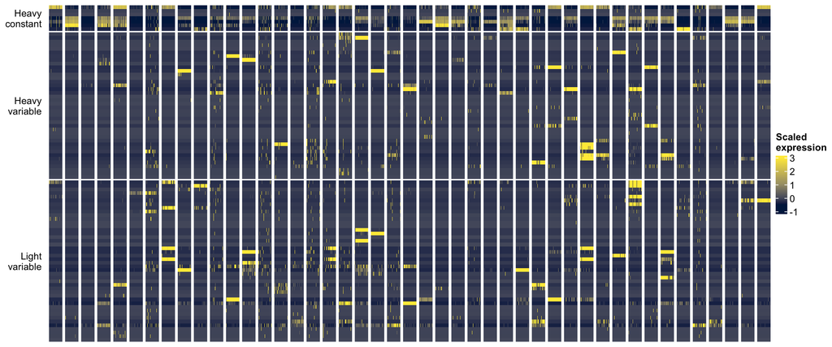

```r
draw(hm)
```

```r
grDevices::png("../figures/S2/B.png", height = 350, width = 1000)
ComplexHeatmap::draw(hm)
grDevices::dev.off()
```

## S2C

- NSD2 = MMSET
- CCND1

```r
# Published translocation information
donor_transloc = data.frame(
  donor_id=c('Maura_2023.PT03','Maura_2023.PT12','Foster_2024.SMM8','Foster_2024.SMM10','Maura_2023.PT30','Maura_2023.PT63'),
  group=c('(4;14)+','(4;14)+','(4;14)+','(4;14)+','(11;14)+','(11;14)+'),
  donor_pl=c("Maura 2023\nPT03\nt(4;14)+","Maura 2023\nPT12\nt(4;14)+",'This study\nSMM-8\nt(4;14)+', 'This study\nSMM-10\nt(4;14)+',"Maura 2023\nPT30\nt(11;14)+","Maura 2023\nPT63\nt(11;14)+"))

# Expression
sce = zellkonverter::readH5AD('../preprocessing/data/import/PC.h5ad')
sce = sce[c('CCND1','NSD2'),sce$donor_id %in% donor_transloc$donor_id]

dat.pl = data.frame(donor_id=sce$donor_id, CCND1=as.vector(assay(sce['CCND1',])),
           MMSET=as.vector(assay(sce['NSD2',]))) %>%
  mutate(mPC = colnames(sce) %in% m_id[m_id$mPC=='True',]$obs_names) %>%
  mutate(mPC = ifelse(mPC,'Tumour (clonal)','Non-tumour (non-clonal)')) %>%
  left_join(donor_transloc) %>%
  select(donor_id,donor_pl,mPC,group,CCND1,MMSET) %>%
  pivot_longer(!c(donor_id:group)) %>%
  mutate(mPC=factor(mPC,levels=c('Non-tumour (non-clonal)','Tumour (clonal)'))) %>%
  mutate(name=factor(name,c('MMSET','CCND1'))) %>%
  mutate(donor_pl=factor(donor_pl,donor_transloc$donor_pl))
```

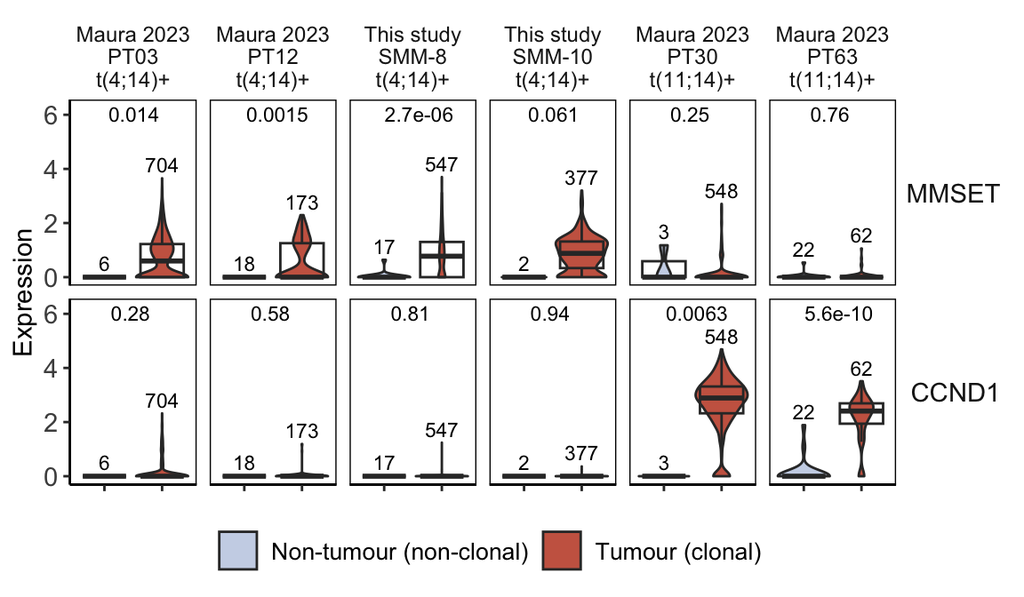

```r
pl.col = c('Tumour (clonal)'='#CB6651','Non-tumour (non-clonal)'='#CBD5E8')

dat.pl %>%
  ggplot(aes(mPC,value))+facet_grid(name~donor_pl)+
  geom_violin(aes(fill=mPC))+geom_boxplot(alpha=0)+
  scale_fill_manual(values = pl.col)+
  stat_summary(fun.data = function(x){c(y = max(x)+0.5, label = length(x))},
    geom = "text", fun.y = median, size=3)+
  ggpubr::stat_compare_means(aes(label = paste0(after_stat(p.format))),
    method='wilcox.test', label.y=5.75,label.x=1.25, size=3)+
  ylim(c(0,6.25))+
  labs(y='Expression', fill='')+
  theme(
    legend.position = 'bottom',
    legend.text = element_text(size=10),
    panel.border = element_rect(color = "black", fill = NA, size = 0.5),
    axis.title.x=element_blank(),axis.text.x = element_blank(),
    axis.text.y = element_text(size=11),
    strip.background=element_blank(),
    strip.text.x = element_text(size=9), strip.text.y=element_text(angle=0, hjust=1, size=11)
  )->pl
pl
```

```r
ggsave(plot=pl,filename = '../figures/S2/C.pdf',width=6,height=3.5, dpi="retina")
```

## S2D

```r
m_id = read.csv('../preprocessing/data/mPC_id.csv')

dat = m_id %>%
  filter(!donor_id %in% donors.longit) %>%
  mutate(mPC=ifelse(mPC,'mPC','hPC')) %>%
  group_by(donor_id,mPC) %>% tally() %>% ungroup() %>%
  group_by(donor_id) %>% mutate(pct=n/sum(n)*100) %>% ungroup() %>%
  left_join(da_md %>% select(donor_id,diagnosis) %>% distinct()) %>%
  mutate(diagnosis=factor(diagnosis,c('MGUS','SMM','MM'))) %>% distinct()
```

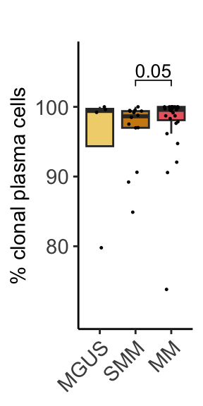

```r
dat %>% filter(mPC=='mPC') %>%
  ggplot(aes(x = diagnosis, y = pct, fill=diagnosis))+
  geom_boxplot(outlier.alpha = 0)+
  geom_jitter(width=0.2,height=0,size=0.2)+
  ggpubr::stat_compare_means(comparisons = list(c('SMM','MM')),method = 'wilcox.test',size=3.5,label.y=102.5)+
  scale_y_continuous(limits = c(70,107.5), breaks = c(80,90,100))+
  scale_fill_manual(values=diagnosis_col)+
  labs(x='',y='% clonal plasma cells',title='')+
  theme_classic()+
  theme(
    legend.position = "none",
    plot.title = element_text(hjust = 0.5, size=12),
    axis.title.x = element_blank(),
    axis.text.x = element_text(angle = 45, vjust = 1, hjust=1, size=11),
    axis.title.y = element_text(size=11),
    axis.text.y = element_text(size=11)
    )-> pl
pl
```

```r
ggsave(plot=pl,filename = '../figures/S2/S2D.pdf',width=1.5,height=3, dpi="retina")
```

## S2E

```r
load('../preprocessing/data/tumour_modules_scr.RData')
m_id = read.csv('../preprocessing/data/mPC_id.csv')
full = as.data.frame(scater::makePerCellDF(scr,rownames(scr),exprs_values='scores'))
full = full[rownames(full) %in% m_id$obs_names,]

dat.pl = full %>%
  select(any_of(rownames(scr))) %>% sample_n(10000) %>%
  pivot_longer(everything(),names_to='p') %>%
  left_join(data.frame(p=rownames(scr),pathway=unique(read.csv('../resources/pathways.csv')$pathway_neat)[1:40]))
```

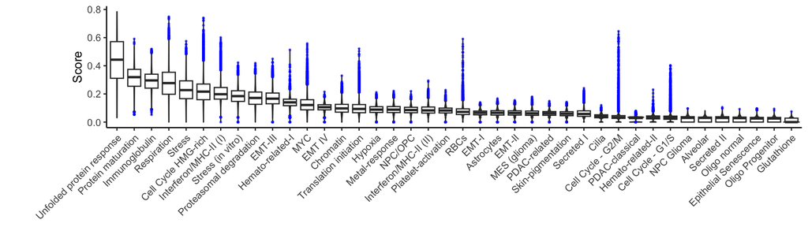

```r
dat.pl.order = dat.pl %>% group_by(pathway) %>%
  summarise(m=median(value)) %>% arrange(-m) %>% pull(pathway)

dat.pl %>%
  mutate(name_pl=factor(pathway,dat.pl.order)) %>%
  ggplot(aes(name_pl,value))+geom_violin()+
  geom_boxplot(outlier.size = 0.5, outlier.colour = 'blue', outlier.alpha = 0.5)+
    theme(axis.text.x = element_text(angle = 45, vjust = 1, hjust=1))+
  labs(y='\n\n\n\n\nScore',x='')-> pl
pl
```

```r
ggsave(plot=pl,filename = '../figures/S2/E.png',width=10,height=3, dpi="retina")
```